# PredictingText

AM

5/20/2020

# Data Import

The code section below outlines the data import process of the three text files for this project.

```r
# Set directories for files
setwd("C:/Users/amanafpour/Desktop/final/en_US")

# Load the dataset
filenames <- list.files(".") #read filenames from directory
dfread <- NULL
dfread <- data.frame(file = character(), lines = character())
linesnmax <- 50000 #Set maximum for number of lines read of each file
for (filename in filenames) {
  lins <- readr::read_lines(filename, n_max = linesnmax)
  newdf <- data.frame(file = filename, lines = lins)
  dfread <- rbind(dfread, newdf)
}
dfread$file<-as.factor(dfread$file)

# Randomly select subset of data
nsamp <- 5000
set.seed(34341)
dftibble <- dfread %>% group_by(file) %>% sample_n(size = nsamp)
df <- as.data.frame(dftibble)

# Generate docs corpus from data frame (1 text doc per input txt file)
docs <- NULL
for (file in levels(df$file)){
  subdf <- df[which(df$file == file),]
  doc_str <- paste(subdf$lines, collapse = "\n")
  #Initiate corpus if it doesn't exist and set the ptd's meta data
  tempdoc <- VCorpus(VectorSource(doc_str),
                     readerControl = list(reader=readPlain, language = "en"))
  meta(tempdoc[[1]])$id <- file
  if (is.null(docs)) {docs <- tempdoc}
  else {docs <- c(docs, tempdoc)}
}
```

It is worth noting, for testing purposes and RAM limitations, the first **50000** lines were read from each input file and then only a small subset (**5000** samples per input file) was selected with equal number of samples per input file to generate the corpora for analysis.

# Data Cleaning

The function defined below cleans the corpus. Profanity is removed but only the most explicit swear words. Removal of stopwords is left as an option for the function because we may wan to include them in the prediction model.

```r
# Punctuation to be removed during tokenization, not here, because periods '.' will be
# used to determine sentences in the tokenization section.
Clean_Corpus <- function(corpus, removeStpwrds = T){
  # Lowercase
  corpus <- tm_map(corpus, content_transformer(tolower))
  # Remove numbers
  corpus <- tm_map(corpus, removeNumbers)
  # Remove explicitly profane words
  profanity <- readLines("http://www.bannedwordlist.com/lists/swearWords.txt")
  corpus <- tm_map(corpus, removeWords, profanity)
  # Remove extra whitespace BUT maintain \n line breaks
  whitespaceFUN <- content_transformer(function(x) gsub("[ ]+", " ",as.String(x)))
  corpus <- tm_map(corpus, whitespaceFUN)
  # Remove stop words if required
  if (removeStpwrds == T) {
    corpus <- tm_map(corpus, removeWords, words = stopwords("en"))
    }
  return(corpus)
}
docs <- Clean_Corpus(docs)
```

# Tokenization

A custom function is defined for n-gram tokenization that is used in the DocumentTermMatrix control options. The Get_Freq function summarizes all rows in the matrix into one vector and the getDoc_ByID function is defined if we want to extract a row from the corpus to evaluate independently.

```r
# ngram tokenization function
ngramTokenizer <- function(x, n){
    sens <- unlist(lapply(tokenize_lines(as.String(x)), tokenize_sentences), use.names = F)
    ngrams <- unlist(tokenize_ngrams(sens, n=n, lowercase = F))
    ngrams[!is.na(ngrams)]
  }

Get_dtm <- function(corpus, n = 1, rmvPunc = T){
  if (n == 1){
    dtm <- DocumentTermMatrix(corpus, control = list(removePunctuation = rmvPunc))
    }
  else {
    dtm <- DocumentTermMatrix(corpus,
                                control = list(removePunctuation = T,
                                               tokenize = function(x) ngramTokenizer(x,n)))
  }
  return(dtm)
}

# Get_Freq summarizes all rows in the document-term matrix into one vector
Get_Freq <- function(dtminput){
  freq <- colSums(as.matrix(dtminput))
  ord <- order(freq, decreasing = T)
  freq <- freq[ord]
  return(freq)
}

# Custom function for getting doc from corpus
getDoc_ByID <- function(corpus, id) corpus[grep(id, unlist(meta(corpus, "id")), fixed = T)]

# Tokenization of single words, 2-grams, and 3-grams
freqWords <- Get_Freq(Get_dtm(docs))
freqWords_blogs <- Get_Freq(Get_dtm(getDoc_ByID(docs, "blogs")))
freqWords_news <- Get_Freq(Get_dtm(getDoc_ByID(docs, "news")))
freqWords_twitter <- Get_Freq(Get_dtm(getDoc_ByID(docs, "twitter")))
freqBigram <- Get_Freq(Get_dtm(docs, n = 2))
freqTrigram <- Get_Freq(Get_dtm(docs, n = 3))
```

# Exploratory Data Analysis

The document-term matrices and n-grams are further evaluated below for all three documents together and separately.

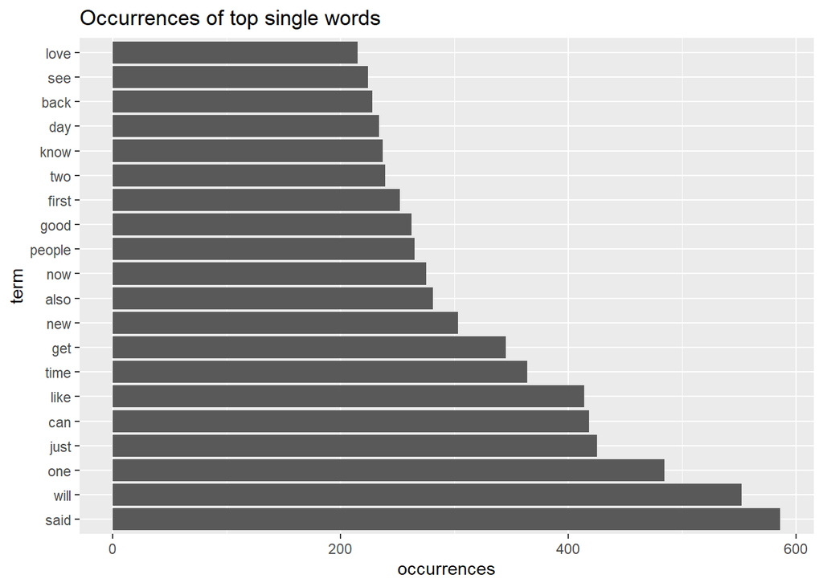

```r
# Function for plotting terms vs occurrences
plot_occurrences <- function(freqplot, nwords = 20){
  wf <- data.frame(term = names(freqplot),
                   occurrences = freqplot,
                   row.names = 1:length(freqplot))[1:nwords,]
  ggplot(wf, aes(term, occurrences)) +
    geom_bar(stat="identity") +
    coord_flip() +
    scale_x_discrete(limits=wf$term)
}

# Plot occurrences of single words, 2-grams, and 3-grams
plot_occurrences(freqWords) + ggtitle("Occurrences of top single words")
```

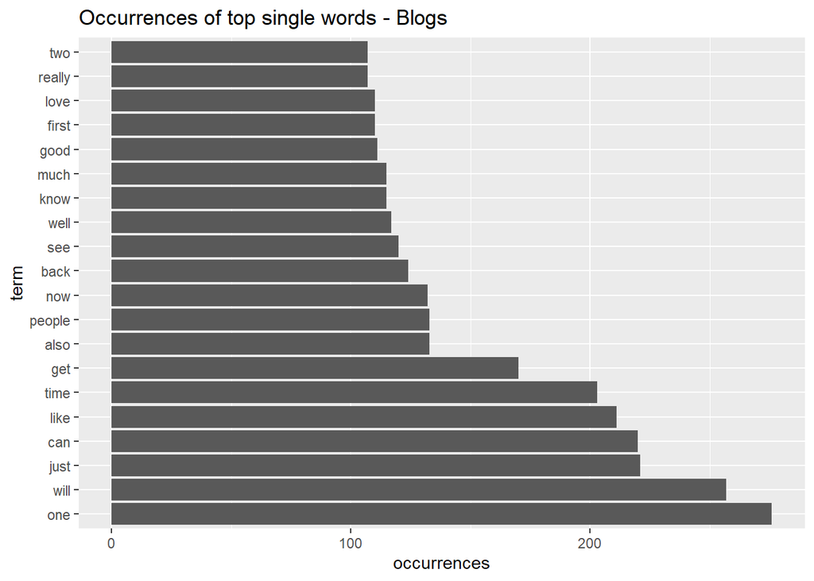

```r
plot_occurrences(freqWords_blogs) + ggtitle("Occurrences of top single words - Blogs")
```

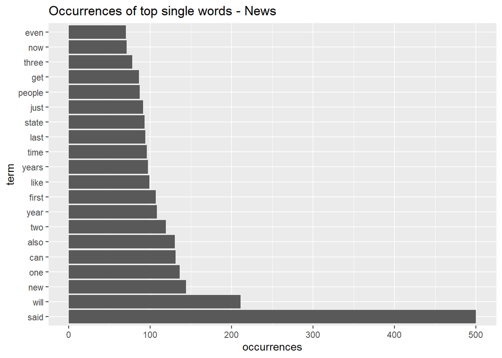

```r
plot_occurrences(freqWords_news) + ggtitle("Occurrences of top single words - News")
```

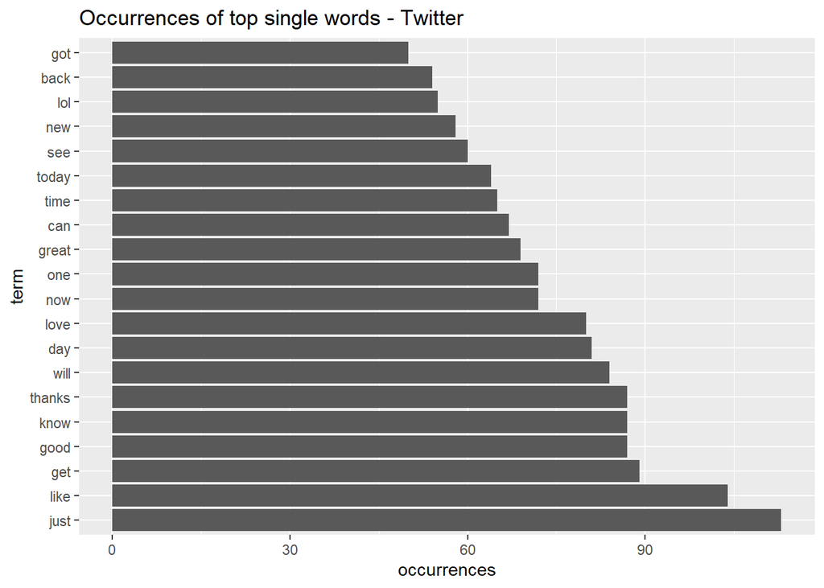

```r
plot_occurrences(freqWords_twitter) + ggtitle("Occurrences of top single words - Twitter")
```